# IE360 HW2

Baran Kırkgöz

2022-05-14

## Introduction

In this homework quarterly gasoline and diesel sales (in 1000 m3) of a major distributor between 2000 and 2006 is analyzed and then, the relationship of this data with another number of potential independent variable is investigated.

##Data prepartion

Before going into analyzing part, the data is prepared. Firstly all the variable types are set to numeric, then the columns are renamed. After these steps, the date column is added in quarters and first column is deleted.

```r
   library(stringr)
    library(zoo)
    library(dplyr)
    library(lubridate)
```

```r
    library(ggplot2)
    library(forecast)
library(readr)
library(GGally)
library(data.table)
library(MASS)
gasoline1 <- read_csv("IE360_Spring22_HW2_data.csv",
    col_types = cols(Quarter = col_number(),
        `Unleaded Gasoline Sale (UGS)` = col_number(),
        RNUV = col_number(), `Price of Unleaded Gasoline (PU)` = col_number(),
        `Price of Diesel Gasoline (PG)` = col_number(),
        `# of Diesel Gasoline Vehicles (NDGV)` = col_number()))

gasoline<-gasoline1[,-1]


gasoline<- gasoline[-c(29:32),]
```

```r
gasoline<-gasoline%>%
  rename(
    UGS=`Unleaded Gasoline Sale (UGS)`,
    NLPG=`# LPG Vehicles (NLPG)`,
    PU= `Price of Unleaded Gasoline (PU)`,
    PG= `Price of Diesel Gasoline (PG)`,
    NUGV=`# Unleaded Gasoline Vehicles (NUGV)`,
    NDGV= `# of Diesel Gasoline Vehicles (NDGV)`,
    GNP_A= `GNP Agriculture`,
    GNP_C = `GNP Commerce`,
    GNP_T= `GNP Total`
  )
```

```r
    gasoline$NLPG<-str_replace_all(gasoline$NLPG, fixed(" "), "")
    gasoline$NUGV<-str_replace_all(gasoline$NUGV, fixed(" "), "")
    gasoline$GNP_A<-str_replace_all(gasoline$GNP_A, fixed(" "), "")
    gasoline$GNP_C<-str_replace_all(gasoline$GNP_C, fixed(" "), "")
    gasoline$GNP_T<-str_replace_all(gasoline$GNP_T, fixed(" "), "")
    gasoline$NLPG<-as.numeric(gasoline$NLPG)
    gasoline$NUGV<-as.numeric(gasoline$NUGV)
    gasoline$GNP_A<-as.numeric(gasoline$GNP_A)
    gasoline$GNP_C<-as.numeric(gasoline$GNP_C)
    gasoline$GNP_T<-as.numeric(gasoline$GNP_T)
```

```r
    date = c("2000-01-01", "2000-04-01", "2000-08-01", "2000-12-01",
             "2001-01-01", "2001-04-01", "2001-08-01", "2001-12-01",
             "2002-01-01", "2002-04-01", "2002-08-01", "2002-12-01",
             "2003-01-01", "2003-04-01", "2003-08-01", "2003-12-01",
             "2004-01-01", "2004-04-01", "2004-08-01", "2004-12-01",
             "2005-01-01", "2005-04-01", "2005-08-01", "2005-12-01",
             "2006-01-01", "2006-04-01", "2006-08-01", "2006-12-01"
             )

    date=as.yearqtr(date, format= "%Y-%m-%d")

    gasoline$date= date
```

##Data Visualization

From the graph it can be understood that there is an decreasing trend. Also, the varience is relatively smaller in the middle.

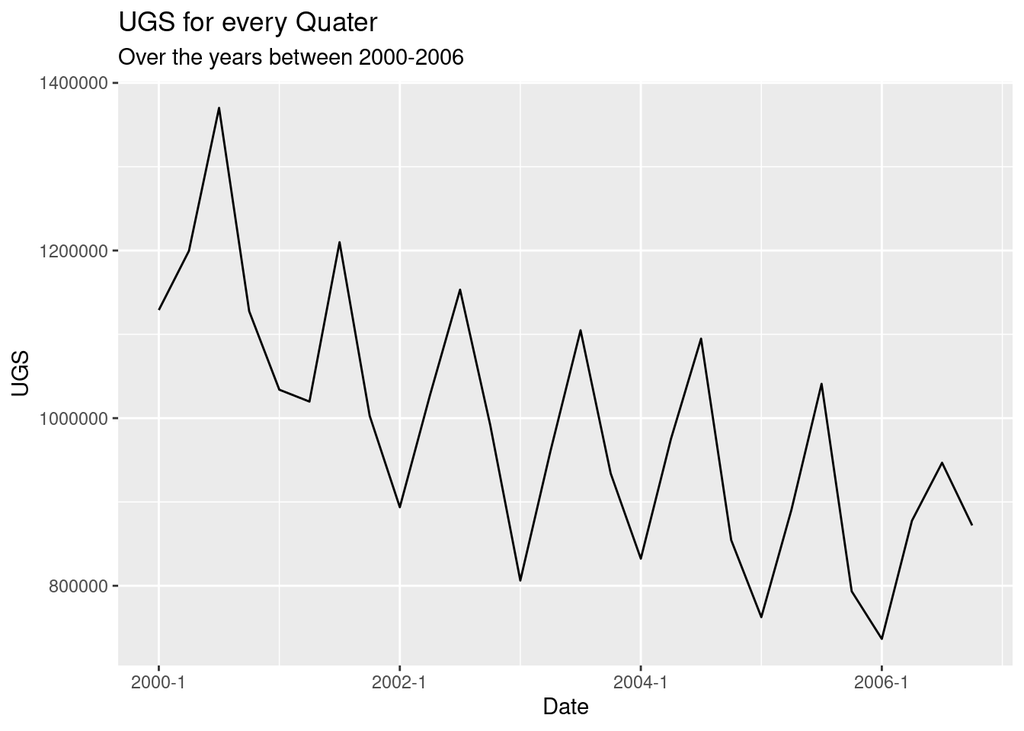

```r
   ggplot(gasoline,aes(x=date,y=UGS))+
      geom_line()+
      labs(x="Date",
           y="UGS",
           title="UGS for every Quater",
           subtitle="Over the years between 2000-2006")
```

To analyze the trend and also other time series components, the datats is created and then decomposed. It can be easily seen that the data is not stationary and also there is an seasonal effect in q3 in every year.Because of this reasons trend component is added to model.

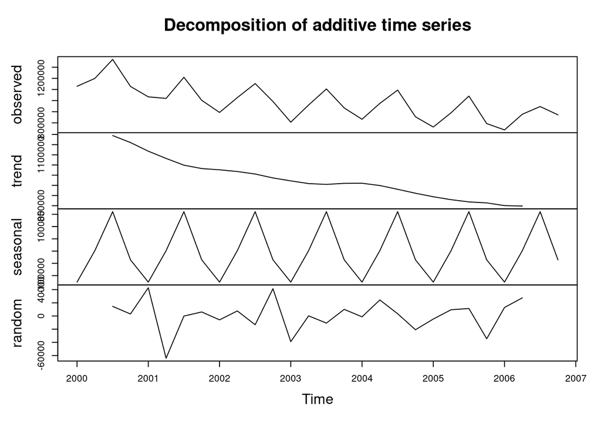

```r
datats <- ts(gasoline$UGS,freq=4,start=c(2000,1))
decomposed_data <- decompose(datats, "additive")
plot(decomposed_data)
```

```r
gasoline$trend=c(1:28)
Q=seq(1,4,by=1)
gasoline=cbind(gasoline,Q)
```

##Analyzing Autocorrelation

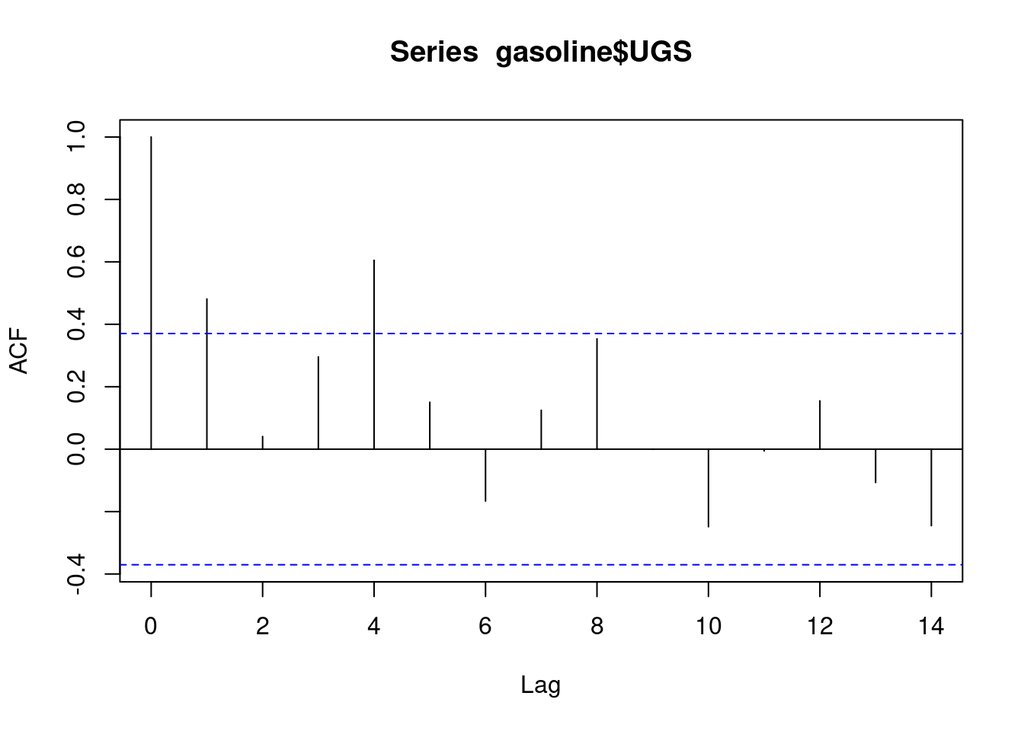

```r
acf(gasoline$UGS)
```

```r
gasoline<-gasoline%>%
  mutate(lag4=lag(UGS,4),
         lag1=lag(UGS,1),
         lag8=lag(UGS,8))
```

##Creating Model

First, the relationship between variables should be anaylzed.

[figure not shown]

```r
ggpairs(gasoline[,-11])
```

The correlation values between UGS and NLPG, NUGV, GNPA, NDGV, and lag 4 values are high.

##Fitting the Model

For the first model, only trend variable is included. The aim is to achieve residual with mean 0 and constant varience.

```r
model1 <- lm(gasoline$UGS~trend, data = gasoline)
summary(model1)
```

```
##
## Call:
## lm(formula = gasoline$UGS ~ trend, data = gasoline)
##
## Residuals:
##     Min      1Q  Median      3Q     Max
## -199945  -73550  -21904   71224  237369
##
## Coefficients:
##             Estimate Std. Error t value Pr(>|t|)
## (Intercept)  1170777      43292  27.043  < 2e-16 ***
## trend         -12660       2608  -4.854 4.95e-05 ***
## ---
## Signif. codes:  0 '***' 0.001 '**' 0.01 '*' 0.05 '.' 0.1 ' ' 1
##
## Residual standard error: 111500 on 26 degrees of freedom
## Multiple R-squared:  0.4754, Adjusted R-squared:  0.4552
## F-statistic: 23.56 on 1 and 26 DF,  p-value: 4.945e-05
```

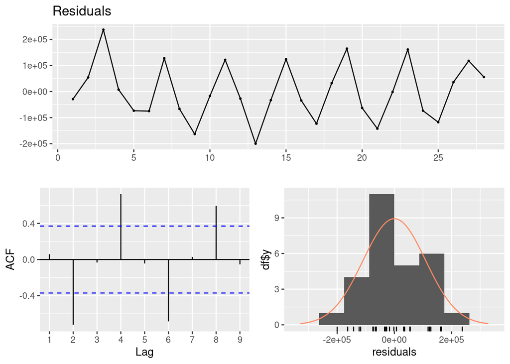

```
##
##  Breusch-Godfrey test for serial correlation of order up to 6
##
## data:  Residuals
## LM test = 19.942, df = 6, p-value = 0.002836
```

```r
checkresiduals(model1)
```

As there can be seen above, autocorrelation is high. So in the second model, lag4 is included.

```r
model2 <- lm(gasoline$UGS~trend+lag4, data = gasoline)
summary(model2)
```

```
##
## Call:
## lm(formula = gasoline$UGS ~ trend + lag4, data = gasoline)
##
## Residuals:
##    Min     1Q Median     3Q    Max
## -66549 -42583   -989  47813  81027
##
## Coefficients:
##              Estimate Std. Error t value Pr(>|t|)
## (Intercept) 8.371e+04  1.178e+05   0.710    0.485
## trend       2.084e+03  1.960e+03   1.063    0.300
## lag4        8.254e-01  9.262e-02   8.912  1.4e-08 ***
## ---
## Signif. codes:  0 '***' 0.001 '**' 0.01 '*' 0.05 '.' 0.1 ' ' 1
##
## Residual standard error: 49740 on 21 degrees of freedom
##   (4 observations deleted due to missingness)
## Multiple R-squared:  0.8525, Adjusted R-squared:  0.8385
## F-statistic: 60.69 on 2 and 21 DF,  p-value: 1.87e-09
```

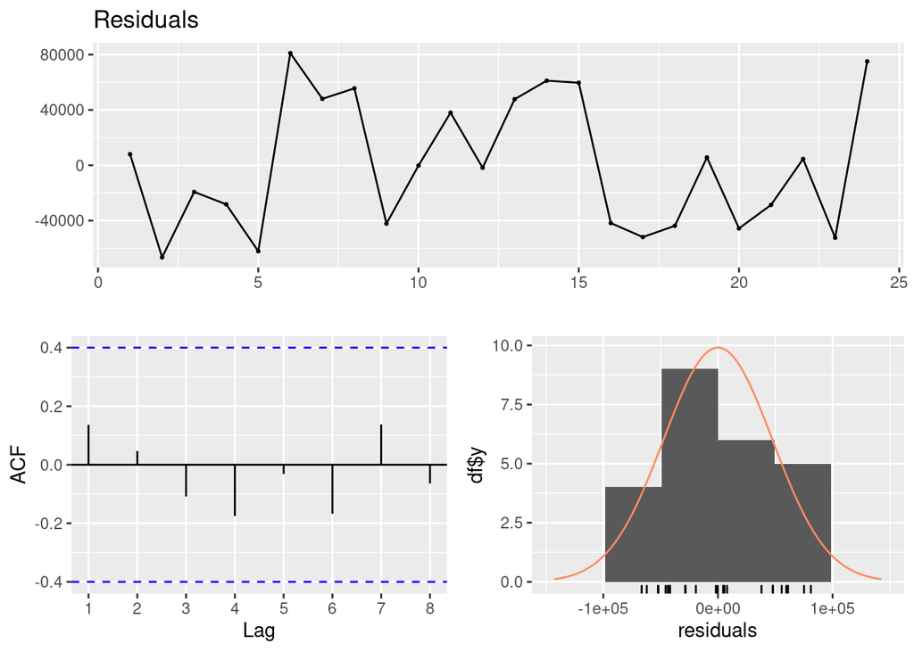

```
##
##  Breusch-Godfrey test for serial correlation of order up to 6
##
## data:  Residuals
## LM test = 2.5252, df = 6, p-value = 0.8656
```

```r
checkresiduals(model2)
```

```r
model3 <- lm(gasoline$UGS~trend+as.factor(Q), data = gasoline)
summary(model3)
```

```
##
## Call:
## lm(formula = gasoline$UGS ~ trend + as.factor(Q), data = gasoline)
##
## Residuals:
##    Min     1Q Median     3Q    Max
## -81167 -31283  -3458  28640  94502
##
## Coefficients:
##               Estimate Std. Error t value Pr(>|t|)
## (Intercept)    1060372      23653  44.830  < 2e-16 ***
## trend           -13497       1147 -11.764 3.28e-11 ***
## as.factor(Q)2   121532      25987   4.677 0.000104 ***
## as.factor(Q)3   273618      26063  10.498 3.03e-10 ***
## as.factor(Q)4    95049      26189   3.629 0.001405 **
## ---
## Signif. codes:  0 '***' 0.001 '**' 0.01 '*' 0.05 '.' 0.1 ' ' 1
##
## Residual standard error: 48570 on 23 degrees of freedom
## Multiple R-squared:  0.9119, Adjusted R-squared:  0.8966
## F-statistic: 59.53 on 4 and 23 DF,  p-value: 8.446e-12
```

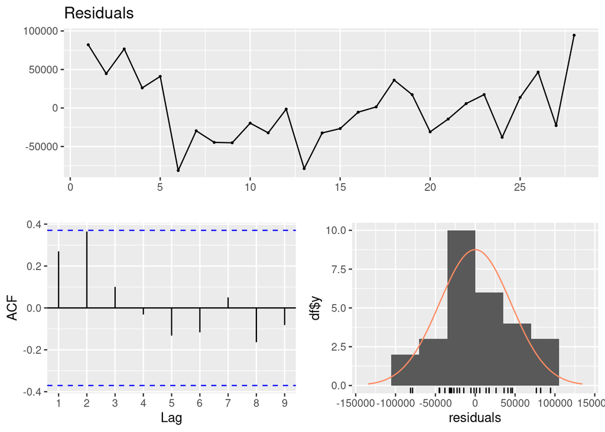

```
##
##  Breusch-Godfrey test for serial correlation of order up to 8
##
## data:  Residuals
## LM test = 11.462, df = 8, p-value = 0.1769
```

```r
checkresiduals(model3)
```

R^2 value is much more higher than model, because of this as.factor(Q) component is chosen over lag4.

Now, the variables with high correlation with UGS will be added to model.

```r
model4 <- lm(gasoline$UGS~trend+as.factor(Q)+ NLPG+PU+PG+NUGV+NDGV+GNP_A , data = gasoline)
summary(model4)
```

```
##
## Call:
## lm(formula = gasoline$UGS ~ trend + as.factor(Q) + NLPG + PU +
##     PG + NUGV + NDGV + GNP_A, data = gasoline)
##
## Residuals:
##    Min     1Q Median     3Q    Max
## -67794 -10461   1987  18461  32208
##
## Coefficients:
##                 Estimate Std. Error t value Pr(>|t|)
## (Intercept)    3.094e+06  8.283e+05   3.735  0.00165 **
## trend          1.514e+04  1.284e+04   1.178  0.25486
## as.factor(Q)2  1.463e+05  2.356e+04   6.212 9.48e-06 ***
## as.factor(Q)3  4.953e+05  1.597e+05   3.102  0.00648 **
## as.factor(Q)4  1.607e+05  4.385e+04   3.664  0.00192 **
## NLPG          -2.937e-01  1.804e-01  -1.628  0.12195
## PU             2.276e+01  1.017e+03   0.022  0.98241
## PG            -1.129e+03  1.437e+03  -0.786  0.44295
## NUGV          -1.023e+00  3.343e-01  -3.061  0.00708 **
## NDGV           1.238e+04  3.581e+03   3.456  0.00302 **
## GNP_A         -3.613e-02  2.764e-02  -1.307  0.20854
## ---
## Signif. codes:  0 '***' 0.001 '**' 0.01 '*' 0.05 '.' 0.1 ' ' 1
##
## Residual standard error: 29700 on 17 degrees of freedom
## Multiple R-squared:  0.9757, Adjusted R-squared:  0.9613
## F-statistic: 68.12 on 10 and 17 DF,  p-value: 1.055e-11
```

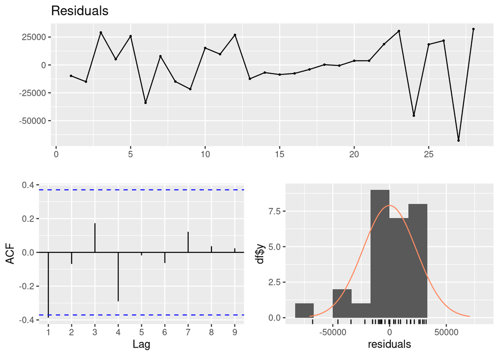

```
##
##  Breusch-Godfrey test for serial correlation of order up to 14
##
## data:  Residuals
## LM test = 26.623, df = 14, p-value = 0.02154
```

```r
checkresiduals(model4)
```

```r
model5 <- lm(gasoline$UGS~trend+as.factor(Q)+NUGV+NDGV , data = gasoline)
summary(model5)
```

```
##
## Call:
## lm(formula = gasoline$UGS ~ trend + as.factor(Q) + NUGV + NDGV,
##     data = gasoline)
##
## Residuals:
##    Min     1Q Median     3Q    Max
## -67804 -17414   3897  19110  59734
##
## Coefficients:
##                 Estimate Std. Error t value Pr(>|t|)
## (Intercept)    1.765e+06  4.825e+05   3.658 0.001467 **
## trend         -6.596e+03  3.908e+03  -1.688 0.106254
## as.factor(Q)2  1.242e+05  1.898e+04   6.543 1.76e-06 ***
## as.factor(Q)3  2.798e+05  1.917e+04  14.592 1.83e-12 ***
## as.factor(Q)4  1.071e+05  1.979e+04   5.412 2.28e-05 ***
## NUGV          -5.356e-01  1.590e-01  -3.369 0.002899 **
## NDGV           6.619e+03  1.421e+03   4.657 0.000135 ***
## ---
## Signif. codes:  0 '***' 0.001 '**' 0.01 '*' 0.05 '.' 0.1 ' ' 1
##
## Residual standard error: 35420 on 21 degrees of freedom
## Multiple R-squared:  0.9572, Adjusted R-squared:  0.945
## F-statistic: 78.32 on 6 and 21 DF,  p-value: 2.816e-13
```

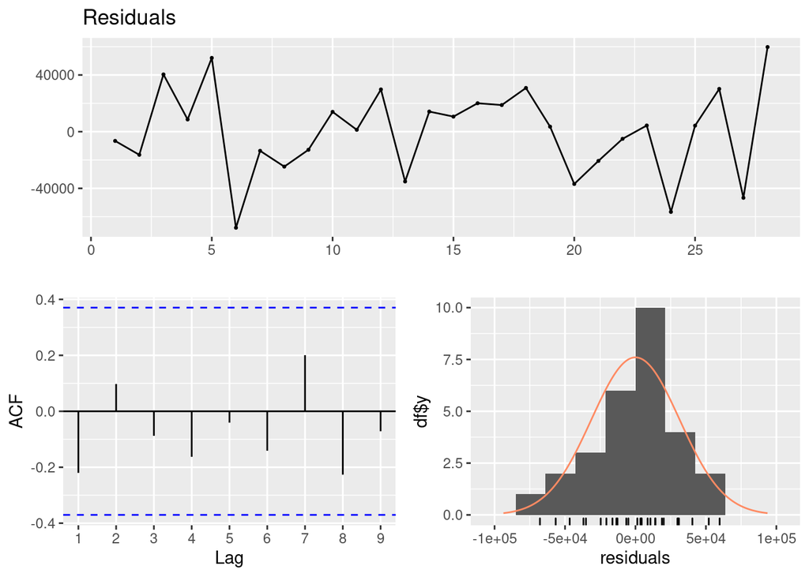

```
##
##  Breusch-Godfrey test for serial correlation of order up to 10
##
## data:  Residuals
## LM test = 14.184, df = 10, p-value = 0.1647
```

```r
checkresiduals(model5)
```

##Evaluation In the final model, adjusted R^2 value is 0.945, which is very high. And also residual vs fitted graph is looking okay. The resudials does not follow a pattern and varience seems constant.

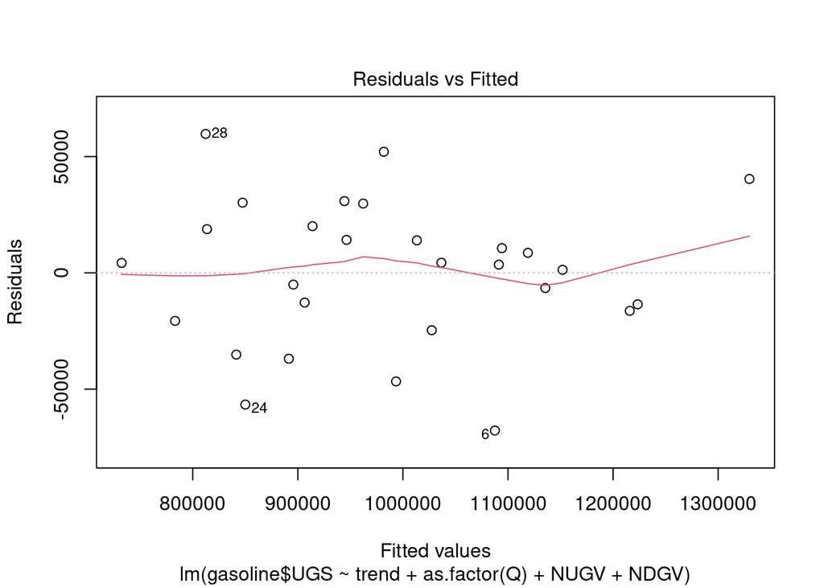

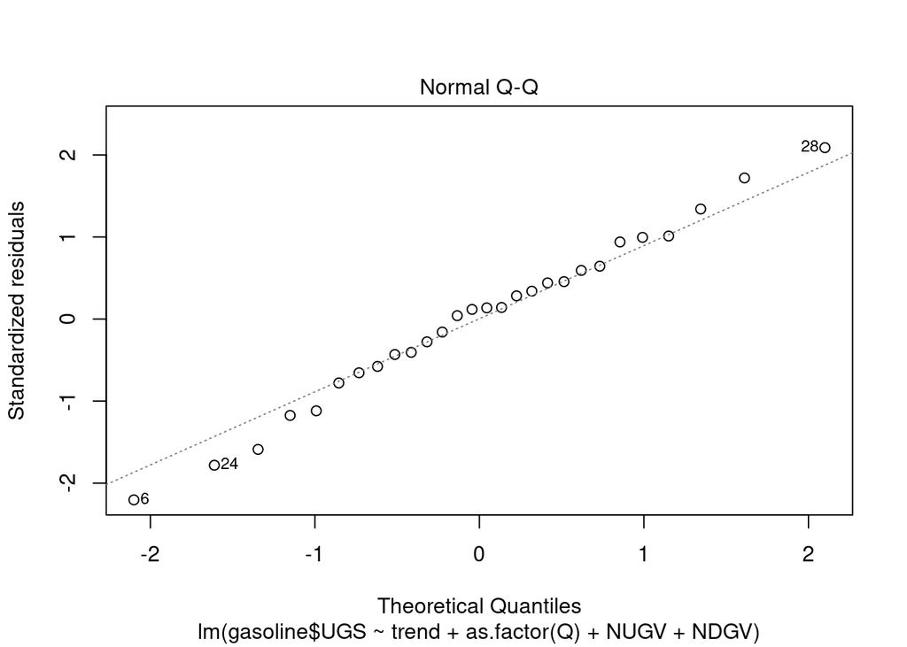

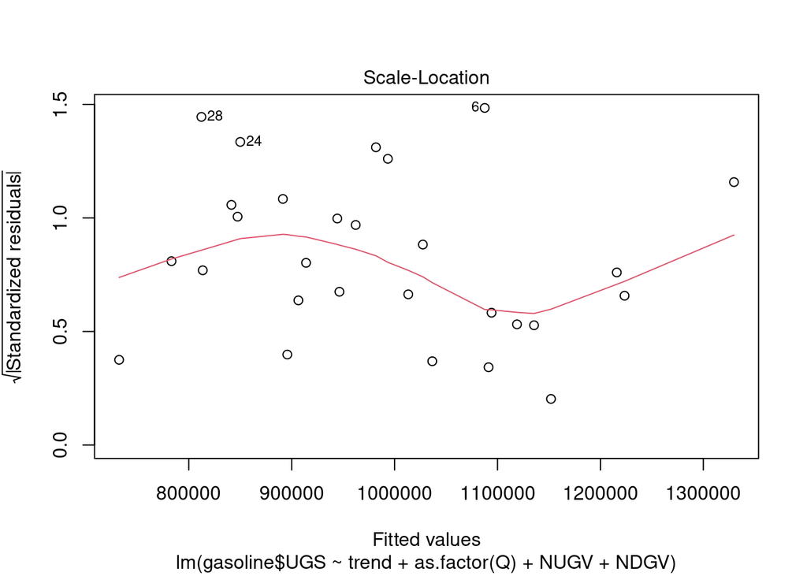

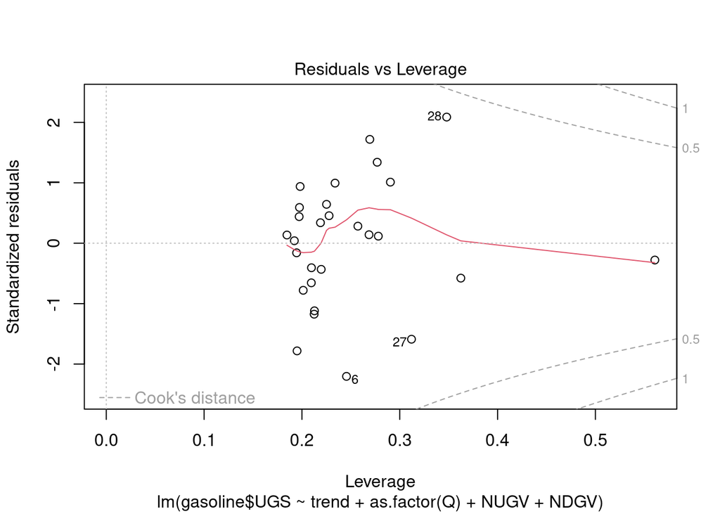

```r
plot(model5)
```

##Prediction

The rows of 2007 was deleted, now there will be created new dataset including datas from 2007

```r
gasoline2=gasoline1[-c(1:28),]
str(gasoline2)
```

```
## tibble [4 × 11] (S3: tbl_df/tbl/data.frame)
##  $ Quarter                             : num [1:4] 2007 2007 2007 2007
##  $ Unleaded Gasoline Sale (UGS)        : num [1:4] NA NA NA NA
##  $ RNUV                                : num [1:4] 0.0074 0.0106 0.0101 0.0124
##  $ # LPG Vehicles (NLPG)               : chr [1:4] "1 715 000" "1 725 300" "1 751 050" "1 797 400"
##  $ Price of Unleaded Gasoline (PU)     : num [1:4] 565 565 565 565
##  $ Price of Diesel Gasoline (PG)       : num [1:4] 449 449 449 449
##  $ # Unleaded Gasoline Vehicles (NUGV) : chr [1:4] "5 869 018" "5 931 348" "5 991 280" "6 065 597"
##  $ # of Diesel Gasoline Vehicles (NDGV): num [1:4] 342 347 351 357
##  $ GNP Agriculture                     : chr [1:4] "1 132 973" "1 570 703" "7 140 722" "2 418 541"
##  $ GNP Commerce                        : chr [1:4] "4 857 305" "5 852 404" "7 480 414" "6 397 745"
##  $ GNP Total                           : chr [1:4] "24 413 807" "27 597 857" "36 741 745" "31 361 112"
```

```r
gasoline2<-gasoline2%>%
  rename(
    UGS=`Unleaded Gasoline Sale (UGS)`,
    NLPG=`# LPG Vehicles (NLPG)`,
    PU= `Price of Unleaded Gasoline (PU)`,
    PG= `Price of Diesel Gasoline (PG)`,
    NUGV=`# Unleaded Gasoline Vehicles (NUGV)`,
    NDGV= `# of Diesel Gasoline Vehicles (NDGV)`,
    GNP_A= `GNP Agriculture`,
    GNP_C = `GNP Commerce`,
    GNP_T= `GNP Total`
  )

    gasoline2$NLPG<-str_replace_all(gasoline2$NLPG, fixed(" "), "")
    gasoline2$NUGV<-str_replace_all(gasoline2$NUGV, fixed(" "), "")
    gasoline2$GNP_A<-str_replace_all(gasoline2$GNP_A, fixed(" "), "")
    gasoline2$GNP_C<-str_replace_all(gasoline2$GNP_C, fixed(" "), "")
    gasoline2$GNP_T<-str_replace_all(gasoline2$GNP_T, fixed(" "), "")
    gasoline2$NLPG<-as.numeric(gasoline2$NLPG)
    gasoline2$NUGV<-as.numeric(gasoline2$NUGV)
    gasoline2$GNP_A<-as.numeric(gasoline2$GNP_A)
    gasoline2$GNP_C<-as.numeric(gasoline2$GNP_C)
    gasoline2$GNP_T<-as.numeric(gasoline2$GNP_T)

   date = c("2007-01-01", "2007-04-01", "2007-08-01", "2007-12-01"

             )

    date=as.yearqtr(date, format= "%Y-%m-%d")

    gasoline2$date= date
    gasoline2$trend=c(1:4)
Q=seq(1,4,by=1)
gasoline2=cbind(gasoline2,Q)
```

Forecasting 2007:

```r
gasoline_pred=gasoline2[,c("UGS","NDGV", "NUGV", "trend", "Q")]

for(i in 1:4) {
  gasoline_pred[i,1] = predict(model5,newdata = gasoline_pred[i,])

}

gasoline_pred
```

```
##         UGS     NDGV    NUGV trend Q
## 1  879614.0 342.1729 5869018     1 1
## 2  995406.0 346.9407 5931348     2 2
## 3 1142070.1 351.4449 5991280     3 3
## 4  961711.8 357.2902 6065597     4 4
```